# Plotting povcal full distributions

Load data prepared by Shahid.

```r
df<- read.csv("full_distribution.csv")
```

Rearranging slightly, this is stored in the following format:

```r
df<- df %>%
  pivot_longer(
    cols = !c(CountryName, RequestYear),
    names_to = "percentile",
    names_prefix = "P",
    names_transform = list(percentile = as.numeric),
    values_to = "daily_income_or_consumption"
  )

head(df)
```

```
## # A tibble: 6 × 4
##   CountryName RequestYear percentile daily_income_or_consumption
##   <chr>             <int>      <dbl>                       <dbl>
## 1 Albania            1981        0                          0.87
## 2 Albania            1981        0.1                        1.53
## 3 Albania            1981        0.2                        1.61
## 4 Albania            1981        0.3                        1.65
## 5 Albania            1981        0.4                        1.88
## 6 Albania            1981        0.5                        1.96
```

I’m not totally sure how Shahid calculated this, and hence not exactly sure what the percentile ‘0.0’ corresponds to.

In any case, it looks like there’s some kinky behaviour at this 0.0 value.

Moreover, steps of 1/10th of a percentile is too high a resolution: it results in e.g. the income threshold of P10.1 and P10.2 being exactly the same (to 2 d.p.).

Let’s only keep whole-number percentiles (i.e. P1, P2… P99).

```r
perc_keep<- seq(1,99,1) # The set of fractiles to keep

df<- df %>%
  filter(percentile %in% perc_keep)
```

## Calculate densities to plot

The classic Gapminder incomes plot is the density (y axis) of log income (x axis).

To calculate (discrete) densities:

- Find the width of the ‘bin’ (distance between the incomes of two adjacent percentiles).

```r
df<- df %>%
  group_by(CountryName, RequestYear) %>%
  mutate(lag_inc=lag(daily_income_or_consumption)) %>%
  mutate(bin_width = daily_income_or_consumption - lag_inc)
```

- The area of each bin is proportional to the ‘step’ in the percentiles. I divide by 100 (%) so that the areas sum to 1. (If you wanted, you could scale by total population at this step).

```r
df<- df %>%group_by(CountryName, RequestYear) %>%
  mutate(lag_percentile=lag(percentile)) %>%
  mutate(percentile_step = percentile - lag_percentile,
         bin_area = percentile_step/100)
```

But plotted against incomes shown on a log scale requires a transformation: you need to multiply the density by income (think chain rule).

```r
df<- df %>%
  group_by(CountryName, RequestYear) %>%
  mutate(density = 1/bin_width) %>% # For linear scale
  mutate(density_for_logs = density * daily_income_or_consumption) # For log scale
```

These density values will be plotted at the midpoint between the income range of the bin.

```r
df<- df %>%
  group_by(CountryName, RequestYear) %>%
  mutate(midpoint_inc = (lag_inc + daily_income_or_consumption)/2)
```

## Plot densities

```r
unique(df$CountryName)
```

```
##   [1] "Albania"
##   [2] "Algeria"
##   [3] "Angola"
##   [4] "Argentina_U"
##   [5] "Armenia"
##   [6] "Australia"
##   [7] "Austria"
##   [8] "Azerbaijan"
##   [9] "Bangladesh"
##  [10] "Belarus"
##  [11] "Belgium"
##  [12] "Belize"
##  [13] "Benin"
##  [14] "Bhutan"
##  [15] "Bolivia"
```

[output cut: 167 more lines]

Filter for countries and years.

```r
select_countries<- c("Kenya", "Other high Income")
select_years<- c(2019)

selected_data<- df %>%
  filter(CountryName %in% select_countries,
         RequestYear  %in% select_years)
```

Plot on a log scale (using transformed density):

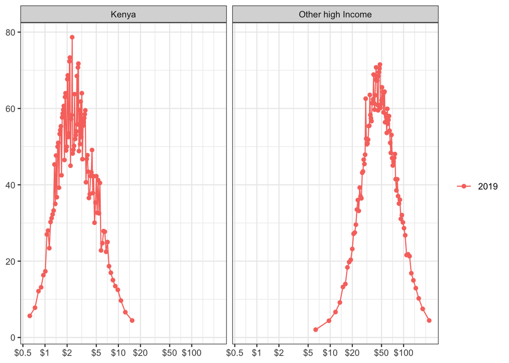

```r
# tick marks
axis_breaks<- log(c(0.5, 1, 2, 5, 10, 20, 50, 100))
axis_labels<- c("$0.5", "$1", "$2", "$5", "$10", "$20", "$50", "$100")

ggplot(selected_data,
       aes(x=log(midpoint_inc), y = density_for_logs, colour = as.factor(RequestYear)))+
  geom_point() +
  geom_line() +
  facet_wrap(~CountryName) +
  scale_x_continuous(breaks=axis_breaks,
                    labels = axis_labels) +
  theme_bw() +
  theme(legend.title = element_blank(),
        axis.title.x = element_blank(),
        axis.title.y = element_blank())
```

On a linear scale:

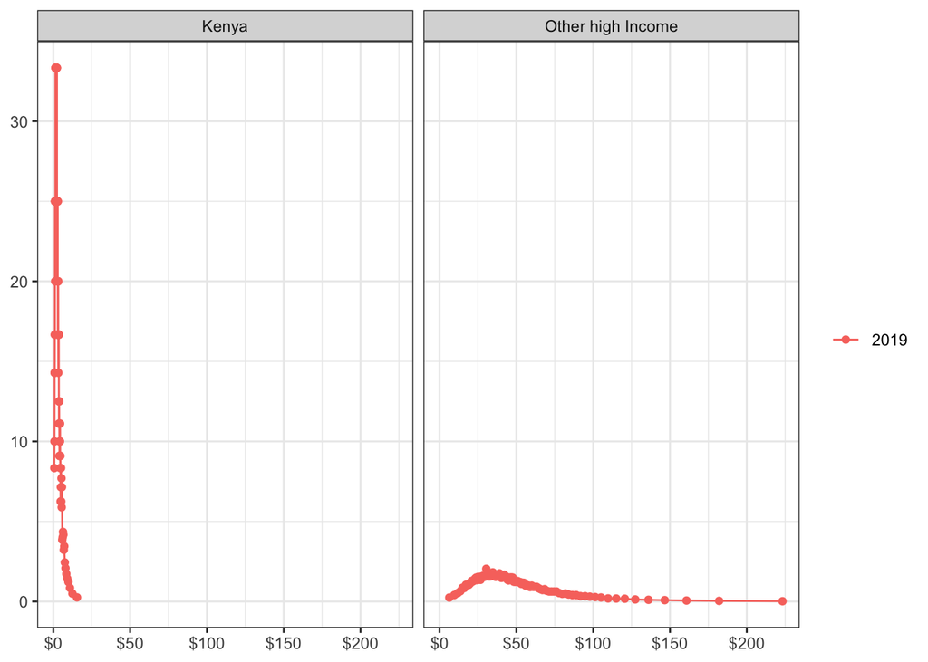

```r
ggplot(selected_data,
       aes(x=midpoint_inc, y = density, colour = as.factor(RequestYear))) +
  geom_point() +
  geom_line() +
  facet_wrap(~CountryName) +
  scale_x_continuous(labels=scales::dollar_format()) +
  theme_bw() +
  theme(legend.title = element_blank(),
        axis.title.x = element_blank(),
        axis.title.y = element_blank())
```

Two countries together:

```r
# tick marks
axis_breaks<- log(c(0.5, 1, 2, 5, 10, 20, 50, 100))
axis_labels<- c("$0.5", "$1", "$2", "$5", "$10", "$20", "$50", "$100")
2
```

```
## [1] 2
```

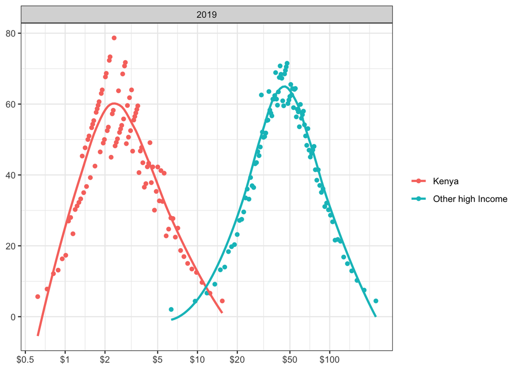

```r
ggplot(selected_data,
       aes(x=log(midpoint_inc), y = density_for_logs, colour = as.factor(CountryName)))+
  geom_point() +
  geom_smooth(se=FALSE) +
  facet_wrap(~RequestYear) +
  scale_x_continuous(breaks=axis_breaks,
                    labels = axis_labels) +
  theme_bw() +
  theme(legend.title = element_blank(),
        axis.title.x = element_blank(),
        axis.title.y = element_blank())
```